# “Code for: **Ecology and sexual conflict drive the macroevolutionary dynamics of female-limited colour polymorphisms**”

#### Hypotheses testing

```r
# Temperate vs tropical in open
LatO_m <- mean(mm5$Sol[,2] - mm5$Sol[,4])
LatO_l <- HPDinterval(mm5$Sol[,2] - mm5$Sol[,4])[1]
LatO_u <- HPDinterval(mm5$Sol[,2] - mm5$Sol[,4])[2]
LatO_p <- sum(mm5$Sol[,2] - mm5$Sol[,4] < 0) / n

# Temperate vs tropical in closed
LatC_m <- mean(mm5$Sol[,1] - mm5$Sol[,3])
LatC_l <- HPDinterval(mm5$Sol[,1] - mm5$Sol[,3])[1]
LatC_u <- HPDinterval(mm5$Sol[,1] - mm5$Sol[,3])[2]
LatC_p <- sum(mm5$Sol[,1] - mm5$Sol[,3] < 0) / n

# Open vs closed in Temperate
HabTmp_m <- mean(mm5$Sol[,2] - mm5$Sol[,1])
HabTmp_l <- HPDinterval(mm5$Sol[,2] - mm5$Sol[,1])[1]
HabTmp_u <- HPDinterval(mm5$Sol[,2] - mm5$Sol[,1])[2]
HabTmp_p <- sum(mm5$Sol[,2] - mm5$Sol[,1] < 0) / n

# Open vs closed in Tropical
HabTrp_m <- mean(mm5$Sol[,4] - mm5$Sol[,3])
HabTrp_l <- HPDinterval(mm5$Sol[,4] - mm5$Sol[,3])[1]
HabTrp_u <- HPDinterval(mm5$Sol[,4] - mm5$Sol[,3])[2]
HabTrp_p <- sum(mm5$Sol[,4] - mm5$Sol[,3] < 0) / n

# combine in dataframe
Dens_tests <- data.frame(Comparsion = c("temperate-open vs tropical-open",
                                      "temperate-closed vs tropical-closed",
                                      "tropical-open vs tropical-closed",
                                      "temperate-open vs temperate-closed"),
                       Mean = c(LatO_m, LatC_m, HabTr_m, HabTmp_m),
                       Lower =  c(LatO_l, LatC_l, HabTrp_l, HabTmp_l),
                       Upper =  c(LatO_u, LatC_u, HabTrp_u, HabTmp_u),
                       PMCMC =  c(LatO_p, LatC_p, HabTrp_p, HabTmp_p))

Dens_tests  %>%
  kbl(booktabs =T, align= c(rep('l',1),rep('r', 4))) %>%
  kable_styling(latex_options ="striped")
```

[output not shown]

```r
#write.table(Dens_tests, file = "../output/glmm/mm5_Htests.tsv", sep = "\t", row.names = F, quote = F)
```

## Are ecological effects mediated by demographic effects?

In *Model 6* we repeat the analysis of ecological effects on the occurrence of FP (*Model 2*), but statistically controlling for the demographic effect of adult density. If ecological effects are indeed entirely mediated by density we expect that once we know the density of a population, knowing its habitat and latitudinal range should not change our believe of the probability of FPs. In other words, the large effect of open habitats in temperate regions should disappear once we control for density.

### Run the model

```r
# we need a matrix of phylogenetic distances to account for shared evolutionary history
inv.phylo <- inverseA(ecotre2, nodes = "TIPS", scale = TRUE)

# residual covariance matrix 1/J*(I+J), I and J are identity and unit matrices respectively
IJ <- (1/3) * (diag(2) + matrix(1, 2, 2))

# kronecker prior for fixed effect close to being flat for the 2 way:
#(0 vs.1 , 1 vs. 2 and 0 vs. 2) marginal probabilities within each fixed effect
pr6 <- list(
  B = list(mu = rep(0, 16), V = diag(16) * (1.7 + pi ^ 2 / 3)),
  R = list(V = IJ, fix = 1),
  G = list(
    G1 = list(
      V = IJ,
      nu = 1000,
      alpha.mu = rep(0, 2),
      alpha.V = diag(2)
    ),
    G2 = list(
      V = 1,
      nu = 1000,
      alpha.mu = rep(0, 1),
      alpha.V = diag(1)
    )
  )
)

#Run the model without intercept to estimate the probability of each state in each combination of latitude and habitat
#starting value
mm6.1 <-
  MCMCglmm(
   relevel(FemState, ref="0") ~ Lat:Hab:trait + Lat:Hab:log(dens):trait -1,
    random = ~ us(trait):Taxon + Site,
    rcov = ~ us(trait):units,
    ginverse = list(Taxon = inv.phylo$Ainv),
    family = "categorical",
    data = ecodat2,
    prior = pr6,
    pl = TRUE,
    slice = TRUE,
    nitt = 1100000,
    burnin = 100000,
    thin = 500,
    verbose = F
  )

mm6.2 <-
  MCMCglmm(
    relevel(FemState, ref="2") ~ Lat:Hab:trait + Lat:Hab:log(dens):trait -1,
    random = ~ us(trait):Taxon + Site,
    rcov = ~ us(trait):units,
    ginverse = list(Taxon = inv.phylo$Ainv),
    family = "categorical",
    data = ecodat2,
    prior = pr6,
    pl = TRUE,
    slice = TRUE,
    nitt = 1100000,
    burnin = 100000,
    thin = 500,
    verbose = F
  )
```

### Make log-odds dataset

```r
LO_dat <- data.frame(model = c(rep("0", 8), rep("1", 8)),
                     Lat = rep(rep(c("Tmp", "Trp"), each = 4), 2),
                     Hab = c(rep(rep(c("C", "O"), each = 1),2), rep(rep(c("C", "O"), each = 1),2)),
                     comp = rep(rep(c("FP vs SM", "FP vs SD"), each = 2), 8),
                     mean = c(mean(mm2.1$Sol[,7]),
                               mean(mm2.1$Sol[,3]),
                               mean(mm2.2$Sol[,8]),
                               mean(mm2.2$Sol[,4]),
                               mean(mm2.1$Sol[,5]),
                               mean(mm2.1$Sol[,1]),
                               mean(mm2.2$Sol[,6]),
                               mean(mm2.2$Sol[,2]),
                               mean(mm6.1$Sol[,1]),
                               mean(mm6.1$Sol[,3]),
                               mean(mm6.2$Sol[,5]),
                               mean(mm6.2$Sol[,7]),
                               mean(mm6.1$Sol[,2]),
                               mean(mm6.1$Sol[,4]),
                               mean(mm6.2$Sol[,6]),
                               mean(mm6.2$Sol[,9])),
                     lwr = c(HPDinterval(mcmc(mm2.1$Sol[,7 ]))[1],
                               HPDinterval(mcmc(mm2.1$Sol[,3 ]))[1],
                               HPDinterval(mcmc(mm2.2$Sol[,8 ]))[1],
                               HPDinterval(mcmc(mm2.2$Sol[,4 ]))[1],
                               HPDinterval(mcmc(mm2.1$Sol[,5 ]))[1],
                               HPDinterval(mcmc(mm2.1$Sol[,1 ]))[1],
                               HPDinterval(mcmc(mm2.2$Sol[,6 ]))[1],
                               HPDinterval(mcmc(mm2.2$Sol[,2 ]))[1],
                               HPDinterval(mcmc(mm6.1$Sol[,1 ]))[1],
                               HPDinterval(mcmc(mm6.1$Sol[,3 ]))[1],
                               HPDinterval(mcmc(mm6.2$Sol[,5 ]))[1],
                               HPDinterval(mcmc(mm6.2$Sol[,7 ]))[1],
                               HPDinterval(mcmc(mm6.1$Sol[,2 ]))[1],
                               HPDinterval(mcmc(mm6.1$Sol[,4 ]))[1],
                               HPDinterval(mcmc(mm6.2$Sol[,6 ]))[1],
                               HPDinterval(mcmc(mm6.2$Sol[,9 ]))[1]),
                     upr = c(HPDinterval(mcmc(mm2.1$Sol[,7 ]))[2],
                               HPDinterval(mcmc(mm2.1$Sol[,3 ]))[2],
                               HPDinterval(mcmc(mm2.2$Sol[,8 ]))[2],
                               HPDinterval(mcmc(mm2.2$Sol[,4 ]))[2],
                               HPDinterval(mcmc(mm2.1$Sol[,5 ]))[2],
                               HPDinterval(mcmc(mm2.1$Sol[,1 ]))[2],
                               HPDinterval(mcmc(mm2.2$Sol[,6 ]))[2],
                               HPDinterval(mcmc(mm2.2$Sol[,2 ]))[2],
                               HPDinterval(mcmc(mm6.1$Sol[,1 ]))[2],
                               HPDinterval(mcmc(mm6.1$Sol[,3 ]))[2],
                               HPDinterval(mcmc(mm6.2$Sol[,5 ]))[2],
                               HPDinterval(mcmc(mm6.2$Sol[,7 ]))[2],
                               HPDinterval(mcmc(mm6.1$Sol[,2 ]))[2],
                               HPDinterval(mcmc(mm6.1$Sol[,4 ]))[2],
                               HPDinterval(mcmc(mm6.2$Sol[,6 ]))[2],
                               HPDinterval(mcmc(mm6.2$Sol[,9 ]))[2])
                               )
```

### Plot final log odds data

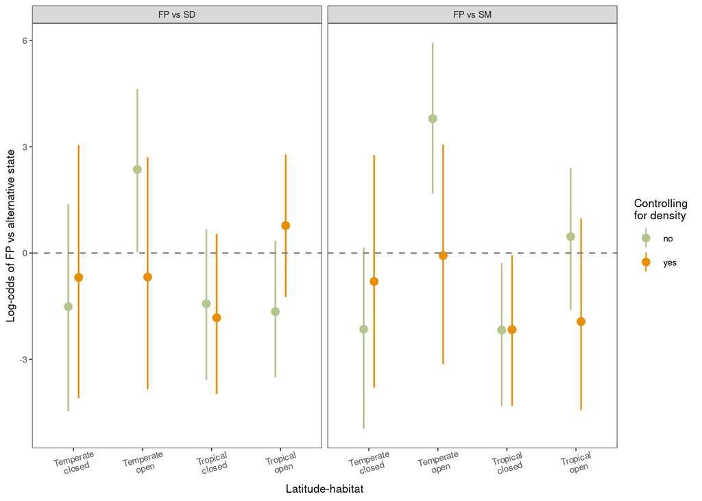

```r
LO_dat$eco <- paste(LO_dat$Lat, LO_dat$Hab, sep = "-")

p6 <- ggplot(data = LO_dat, aes(x = eco, y = mean, colour = model)) +
  geom_pointrange(aes(ymin = lwr, ymax = upr), position = position_dodge(width = 0.3), size = 0.4) +
  labs(y="Log-odds of FP vs alternative state", x = "Latitude-habitat")+
  facet_wrap(~comp) +
  geom_hline(yintercept = 0, colour = "grey50", lty=2)+
   scale_color_manual(breaks = c("0", "1"),
                     values = c(pal[c(5,9)]),
                     labels = c("no", "yes"),
                     name = "Controlling \nfor density") +
  scale_x_discrete(labels = c(
      "Temperate\nclosed",
      "Temperate\nopen",
      "Tropical\nclosed",
      "Tropical\nopen"
    )) +
  theme_bw(base_size = 8) +
  theme(panel.grid.major = element_blank(), panel.grid.minor = element_blank())+
  theme(axis.text.x =  element_text(angle = 15, vjust = 0.85))

p6
```

```r
#ggsave(p6, filename = "~/Dropbox/Doctorado/COEN_Comparative/Writing/Figures/Log-odds_mediator.pdf", device = "pdf", units = "mm", width =100, height = 70)
```

Hadfield J.D. 2010. [MCMC methods for multi-response generalized linear mixed models: The MCMCglmm R package](https://doi.org/doi:10.18637/jss.v033.i02). Journal of Statistical Software. 33:1–22.

Höhna S., Landis M.J., Heath T.A., Boussau B., Lartillot N., Moore B.R., Huelsenbeck J.P., Ronquist F. 2016. RevBayes: Bayesian phylogenetic inference using graphical models and an interactive model-specification language. Systematic Biology. 65:726–736.

Willink B., Ware J., Svensson E.I. 2024. Tropical origin, global diversification and dispersal in the pond damselflies (Coenagrionoidea) revealed by a new molecular phylogeny. Systematic Biology. syae004.